# Could Trump's Tweets Influence the Stock Market?

## Introduction

Today we will look into the data science pipeline, in other words, what is the process by which we **do** data science?

In order to do so, we will take as an example Donald Trump's tweets. Donald Trump tweeted a lot before he was permanently banned in January of 2021, and in many of those tweets, he mentioned publicly traded companies.

### Motivation

Were the value of the stocks of these companies influenced in any way by his tweets? This is a very hard question to answer, perhaps impossible today. The reason why is because the stock market is extremely volatile and can be influenced by tons of factors, and Trump's tweets were only one of them.

However, instead of trying to answer this question, it is easier and more reasonable to attempt to prove or disprove the following null hypothesis: "**Trump's tweets had no influence in the stock market**." How could we determine that?

### Proving or Disproving the Hypothesis

There is no ideal way prove or disprove the null hypothesis, since when dealing with margins of error, they are different from discipline to discipline. In our case, we will choose a 5% margin of error. This means that, if we see that investing in what Trump tweeted, would've yielded more than a 5% profit than our control (S&P500), then we will feel confident enough to disprove the null hypothesis.

If we disprove the null hypothesis, does that mean that Trump's tweets influenced the stock market? **NO!** All it means, is that we have enough evidence to say that, *it is not the case that Trump's tweets didn't influence the stock market*. This distinction is subtle, but important. More information on this subject can be found [here](https://www.investopedia.com/terms/n/null_hypothesis.asp).

## What we will do

We will collect Donald Trump's tweets from September 1st 2016 onwards (until his permanent ban in January 2021), as well as the stock prices of the Top 25 stocks of the S&P500 in 2016. Using all this data, along with Natural Language Processing, we will attempt to determine whether we may or may not disprove the null hypothesis established above. As a control and reference, we will use the S&P500 price throughout the observed time.

In order to do this tutorial, we will follow the Data Science pipeline, which can be seen below.

[figure not shown]

We will be following these steps closely. Notice that they are not necessarilly linear, as at any given point we might go back to a previous step. The tutorial will follow the following format:

- Setup
- Data Collection
- Data Processing
- More Data Collection
- More Data Processing
- Exploratory phase
- Analysis and Hypothesis testing
- Insight and Conclusions

**Inspiration**: This project has been inspired by Max Brown's [Trump2Cash](https://github.com/maxbbraun/trump2cash) bot. This bot used to work when Trump still had a Twitter account, and would invest in real time depending on whether Trump mentioned a publicly traded company, and whether what he said was positive or negative according to sentiment analysis.

# Setup: Installing and Importing the necessary packages

```python
%%capture
# Installing the necessary packages
!pip install yfinance
!pip install nltk
```

```python
%%capture
from bs4 import BeautifulSoup
import requests as reqs
import pandas as pd
import numpy as np
import matplotlib.pyplot as plt
import csv
import yfinance as yf
from datetime import datetime
import datetime as otherdate
import re
import nltk
nltk.download('vader_lexicon')
```

We will install [yfinance](https://pypi.org/project/yfinance/) to download the stock prices from Yahoo Finance's API, and nltk for using the [vader_lexicon](https://www.nltk.org/_modules/nltk/sentiment/vader.html), which is a NLP Model which can be used for sentiment analysis.

As for the other libraries we are importing, we will be using [BeautifulSoup](https://www.crummy.com/software/BeautifulSoup/bs4/doc/) and requests for webscraping, [pandas](https://pandas.pydata.org/), numpy and csv for the tables we will form, datetime for time and [matplotlib](https://matplotlib.org/) for plotting.

# Part 1: Data Collection

## Getting the Tweets

I will be using [Trump's Twitter Archive](https://www.thetrumparchive.com/), which has been keeping track of every Tweet by Donald Trump (including deleted ones) since September 2016. It's database has older tweets, but any deleted tweets before this time will not be present.

I will assume that the data in the archive is reputable, and I base that assumption on the following statement in the author's [FAQ](https://www.thetrumparchive.com/faq) *"[Trump's Twitter Archive ] It's regularly referenced by FactCheck.org, PolitiFact, Snopes, and Wikipedia, along with almost every major news outlet"*

I've downloaded the CSV file manually. Sadly, because it is stored in Google Drive, there is no good, easy way of downloading it with Python. You can get it here: https://drive.google.com/file/d/1xRKHaP-QwACMydlDnyFPEaFdtskJuBa6/view. I've saved it manually as "tweets.csv".

**NOTE - On missing tweets:** As reliable as the archive may be, deleted tweets have were not recorded from before September 2016. However, we do not know exactly when in September the recording of tweets began. Thus, by starting at September 1st, it is highly probable that a few tweets might have been deleted. This is fine, since it should not affect the overall tutorial, but it is important to state and know this.

```python
tweets_table = pd.read_csv('tweets.csv')
```

```python
tweets_table.head()
```

|  | id | text | isRetweet | isDeleted | device | favorites | retweets | date | isFlagged |
| --- | --- | --- | --- | --- | --- | --- | --- | --- | --- |
| 0 | 98454970654916608 | Republicans and Democrats have both created ou... | f | f | TweetDeck | 49 | 255 | 2011-08-02 18:07:48 | f |
| 1 | 1234653427789070336 | I was thrilled to be back in the Great city of... | f | f | Twitter for iPhone | 73748 | 17404 | 2020-03-03 01:34:50 | f |
| 2 | 1218010753434820614 | RT @CBS_Herridge: READ: Letter to surveillance... | t | f | Twitter for iPhone | 0 | 7396 | 2020-01-17 03:22:47 | f |
| 3 | 1304875170860015617 | The Unsolicited Mail In Ballot Scam is a major... | f | f | Twitter for iPhone | 80527 | 23502 | 2020-09-12 20:10:58 | f |
| 4 | 1218159531554897920 | RT @MZHemingway: Very friendly telling of even... | t | f | Twitter for iPhone | 0 | 9081 | 2020-01-17 13:13:59 | f |

Above we can see the first few entries on the table. Notice we have 9 columns:

- id: Unique Tweet ID
- text: The actual tweet
- isRetweet: Is this tweet a retweet of another tweet? (t/f)
- isDeleted: Was this tweet deleted sometime after being posted? (t/f)*
- device: What device was used to tweet
- favorites: Number of favorites
- date: Date when the tweet was posted, in the format of YYYY-MM-DD hh:mm:ss
- isFlagged: The tweet remained available, but user had to explicitly say they wanted to read it.

[1] All Tweets have been deleted (by Twitter), this refers to having been deleted before Trump was banned.

How many tweets have been archived?

```python
len(tweets_table)
```

```
56571
```

## Getting the Stocks

We will be comparing the risk of investing in stocks to some degree, using as a control the price of the S&P 500. We will first get the list of stocks that we might invest in (depending on what Trump tweeted).

Firstly, we'll get all the stocks from Wikipedia, here: https://en.wikipedia.org/wiki/List_of_S%26P_500_companies.

It contains two tables:

- List of the current S&P500 Companies
- List of changes that ocurred to the S&P500

Since our analysis takes place from September 1st 2016 onwards, we will keep all stocks that were present before this date. In order to make the analysis simpler, since this is a tutorial, we will also get rid of all stocks that were removed, sometime, after September 1st 2016. The reason why is because these stocks might have been removed for several reasons, including merging and being replaced by others. Thus, in order to not deal with these intricacies, we will disregard them entirely.

We will have to use BeautifulSoup to scrape the data for stocks, since Wikipedia has these two tables in the website as an .html file.

```python
# Getting the website
wikipedia = reqs.get('https://en.wikipedia.org/wiki/List_of_S%26P_500_companies')
soup = BeautifulSoup(wikipedia.text)
```

From briefly looking at the website's HTML, we can see that the two tables we are interested in are indeed, table tags. Thus, we can find it using BeautifulSoup's .find()

```python
wiki_tables = soup.findAll('table')
print(f'We found {len(wiki_tables)} tables')
```

```
We found 2 tables
```

From looking at the HTML (omitted) and seeing the length, we know we got the appropriate tables. Now, we can put this into Pandas Dataframes.

```python
wiki_tables = pd.read_html('https://en.wikipedia.org/wiki/List_of_S%26P_500_companies')
current_sp500 = wiki_tables[0]
changes_sp500 = wiki_tables[1]
```

```python
print(f'How many companies are there in the S&P500? {len(current_sp500)}')
current_sp500.head()
```

```
How many companies are there in the S&P500? 505
```

|  | Symbol | Security | SEC filings | GICS Sector | GICS Sub-Industry | Headquarters Location | Date first added | CIK | Founded |
| --- | --- | --- | --- | --- | --- | --- | --- | --- | --- |
| 0 | MMM | 3M | reports | Industrials | Industrial Conglomerates | Saint Paul, Minnesota | 1976-08-09 | 66740 | 1902 |
| 1 | ABT | Abbott Laboratories | reports | Health Care | Health Care Equipment | North Chicago, Illinois | 1964-03-31 | 1800 | 1888 |
| 2 | ABBV | AbbVie | reports | Health Care | Pharmaceuticals | North Chicago, Illinois | 2012-12-31 | 1551152 | 2013 (1888) |
| 3 | ABMD | Abiomed | reports | Health Care | Health Care Equipment | Danvers, Massachusetts | 2018-05-31 | 815094 | 1981 |
| 4 | ACN | Accenture | reports | Information Technology | IT Consulting & Other Services | Dublin, Ireland | 2011-07-06 | 1467373 | 1989 |

```python
print(f'How many changes have ocurred to the S&P500? {len(changes_sp500)}')
changes_sp500.head()
```

```
How many changes have ocurred to the S&P500? 273
```

|  | Date | Added Ticker | Added Security | Removed Ticker | Removed Security | Reason |
| --- | --- | --- | --- | --- | --- | --- |
| 0 | June 4, 2021 | NaN | NaN | HFC | HollyFrontier | Market capitalization change.[6] |
| 1 | June 3, 2021 | OGN | Organon & Co. | NaN | NaN | S&P 500/100 constituent Merck & Co. spun off O... |
| 2 | May 14, 2021 | CRL | Charles River Laboratories | FLIR | FLIR Systems | S&P 500 constituent Teledyne Technologies acqu... |
| 3 | April 20, 2021 | PTC | PTC | VAR | Varian Medical Systems | Siemens Healthineers acquired Varian Medical S... |
| 4 | March 22, 2021 | NXPI | NXP | FLS | Flowserve | Market capitalization change.[9] |

# Part 2: Data Processing. Missing Data? Keeping what we need.

## Processing the Tweets

Now that we have collected the data, and we know what each column is doing, it is important to make sure that we have processed and formatted the data so that we can work with it.

One of the biggest things to check is whether we have missing data or not. Are any of the entries for a column missing? Do any of them have a formatting that we don't expect?

Let's check each row to make sure that the data we are looking at is formatted as we expect, and if its not, let's deal with it. The things we care about keeping are the tweet id, its text, date and whether or not it was a retweet, since that is not an original tweet coming from Trump.

```python
# For every row in the table
for index, row in tweets_table.head().iterrows():

    # Getting the current values for the row
    tweet_id = row['id']
    tweet_text = row['text']
    is_retweet = row['isRetweet']
    is_deleted = row['isDeleted']
    device = row['device']
    favorites = row['favorites']
    retweets = row['retweets']
    date = row['date']
    isFlagged = row['isFlagged']

    row_missing = False

    if not isinstance(tweet_id, int):
        row_missing = True

    if (not isinstance(tweet_text, str)) or tweet_text == '':
        row_missing = True

    if (not isinstance(is_retweet, str)) or (is_retweet != 'f' and is_retweet != 't'):
        row_missing = True

    if (not isinstance(date, str)) or date == '':
        row_missing = True

    if row_missing:
        print(f"Missing data in row: {row}")
        row_missing = False
```

It seems no data is missing from what we are interested in, which is great. This is not always the case, and depending on what is missing, we might have to deal with it in different ways.

If the text of the tweet or its date were missing, that would have been an issue and we'd have to ignore that tweet, since we would have no way of determining whether that tweet might have had an effect. If we didn't know whether it was a retweet or not, it might affect us depending on what we choose to do with that information.

For the sake of this tutorial, we'll get rid of all retweets, and just keep the actual tweets. All other data we can get rid of.

```python
essential_table = tweets_table
essential_table = essential_table.drop(columns=['isDeleted', 'device', 'favorites', 'retweets', 'isFlagged'])
print(f'Length of the table: {len(essential_table)}')
essential_table.head()
```

```
Length of the table: 56571
```

|  | id | text | isRetweet | date |
| --- | --- | --- | --- | --- |
| 0 | 98454970654916608 | Republicans and Democrats have both created ou... | f | 2011-08-02 18:07:48 |
| 1 | 1234653427789070336 | I was thrilled to be back in the Great city of... | f | 2020-03-03 01:34:50 |
| 2 | 1218010753434820614 | RT @CBS_Herridge: READ: Letter to surveillance... | t | 2020-01-17 03:22:47 |
| 3 | 1304875170860015617 | The Unsolicited Mail In Ballot Scam is a major... | f | 2020-09-12 20:10:58 |
| 4 | 1218159531554897920 | RT @MZHemingway: Very friendly telling of even... | t | 2020-01-17 13:13:59 |

As you can see we have now gotten rid of all the columns we don't need. Last thing to do, is to get rid of all the retweets, meaning they have a 't' in the isRetweet column.

If we would actually have to use this column, it might be more convenient to convert it into a more logical type, like a Boolean. However, since we'll get rid of it after keeping only the tweets, we don't need to. We will however, have to check the dates repeatedly, and storing them as strings would make things harder. Thus, we can change those as well.

```python
# Getting rid of retweets
no_retweets = essential_table[essential_table['isRetweet'] == 'f']
print(f'Length of the table without retweets: {len(no_retweets)}')
no_retweets.head()
```

```
Length of the table without retweets: 46694
```

|  | id | text | isRetweet | date |
| --- | --- | --- | --- | --- |
| 0 | 98454970654916608 | Republicans and Democrats have both created ou... | f | 2011-08-02 18:07:48 |
| 1 | 1234653427789070336 | I was thrilled to be back in the Great city of... | f | 2020-03-03 01:34:50 |
| 3 | 1304875170860015617 | The Unsolicited Mail In Ballot Scam is a major... | f | 2020-09-12 20:10:58 |
| 6 | 1223640662689689602 | Getting a little exercise this morning! https:... | f | 2020-02-01 16:14:02 |
| 7 | 1319501865625784320 | https://t.co/4qwCKQOiOw | f | 2020-10-23 04:52:14 |

Now we get rid of the isRetweet column

```python
no_retweets = no_retweets.drop(columns=['isRetweet'])
no_retweets.head()
```

|  | id | text | date |
| --- | --- | --- | --- |
| 0 | 98454970654916608 | Republicans and Democrats have both created ou... | 2011-08-02 18:07:48 |
| 1 | 1234653427789070336 | I was thrilled to be back in the Great city of... | 2020-03-03 01:34:50 |
| 3 | 1304875170860015617 | The Unsolicited Mail In Ballot Scam is a major... | 2020-09-12 20:10:58 |
| 6 | 1223640662689689602 | Getting a little exercise this morning! https:... | 2020-02-01 16:14:02 |
| 7 | 1319501865625784320 | https://t.co/4qwCKQOiOw | 2020-10-23 04:52:14 |

Now we can convert the date column to be in a usable date format we can do queries and comparisons in. We will use the *datetime* package to do this, specifically the strptime method. Here's an example:

```python
datetime.strptime('1970-01-01 00:00:00', '%Y-%m-%d %H:%M:%S')
```

```
datetime.datetime(1970, 1, 1, 0, 0)
```

Why convert the dates? This will make it easier for when we have to keep only certain dates. After all, this archive contains tweets from before September 2016, which we will want to get rid of.

```python
# We can do this conveniently applying a simple function over the whole column
# The function will convert the string representation of the date into a datetime object
def str_to_time(s):
    return datetime.strptime(s, '%Y-%m-%d %H:%M:%S')

tweets = no_retweets
tweets['date'] = tweets['date'].apply(str_to_time)
tweets.head()
```

|  | id | text | date |
| --- | --- | --- | --- |
| 0 | 98454970654916608 | Republicans and Democrats have both created ou... | 2011-08-02 18:07:48 |
| 1 | 1234653427789070336 | I was thrilled to be back in the Great city of... | 2020-03-03 01:34:50 |
| 3 | 1304875170860015617 | The Unsolicited Mail In Ballot Scam is a major... | 2020-09-12 20:10:58 |
| 6 | 1223640662689689602 | Getting a little exercise this morning! https:... | 2020-02-01 16:14:02 |
| 7 | 1319501865625784320 | https://t.co/4qwCKQOiOw | 2020-10-23 04:52:14 |

Now, the last step we need to do in order to have our data ready, is to limit the tweets we'll be looking at by time. The archive we are using began archiving Trump's tweets on September of 2016, so any tweets that might have been deleted beforehand are not available.

It is also the case that Donald Trump became a more influential figure around this time, as he was campaigning and later became the president of the United States.

Thus, we'll get rid of all tweets posted before September 1st, 2016. We can use simple comparison of two datetime objects to determine which one is oldest. So, we'll compare all tweets to September 1st, 2016. If they're older, we'll get rid of them.

```python
september_onwards = tweets
filter_date = datetime(2016, 8, 31, 23, 59, 59)

september_onwards = september_onwards[september_onwards['date'] > filter_date]

print(f'Number of tweets, September 2016 onwards: {len(september_onwards)}')
september_onwards.sort_values(by=['date']).head()
```

```
Number of tweets, September 2016 onwards: 17788
```

|  | id | text | date |
| --- | --- | --- | --- |
| 40259 | 771145576381427712 | Hillary Clinton didn't go to Louisiana, and no... | 2016-09-01 00:40:07 |
| 40257 | 771146302134423552 | Great trip to Mexico today - wonderful leader... | 2016-09-01 00:43:00 |
| 40256 | 771150050940497920 | Just arrived in Arizona! #ImWithYouhttps://t.c... | 2016-09-01 00:57:54 |
| 40253 | 771210555822477313 | Mexico will pay for the wall - 100%!#MakeAmeri... | 2016-09-01 04:58:19 |
| 40252 | 771210697552166913 | There will be no amnesty!#MakeAmericaGreatAgai... | 2016-09-01 04:58:53 |

We have now finished processing the tweets. We now move on to processing the stocks.

## Processing the Stocks

### Keeping the necessary columns, formatting and handling missing data

```python
current_sp500.head()
```

|  | Symbol | Security | SEC filings | GICS Sector | GICS Sub-Industry | Headquarters Location | Date first added | CIK | Founded |
| --- | --- | --- | --- | --- | --- | --- | --- | --- | --- |
| 0 | MMM | 3M | reports | Industrials | Industrial Conglomerates | Saint Paul, Minnesota | 1976-08-09 | 66740 | 1902 |
| 1 | ABT | Abbott Laboratories | reports | Health Care | Health Care Equipment | North Chicago, Illinois | 1964-03-31 | 1800 | 1888 |
| 2 | ABBV | AbbVie | reports | Health Care | Pharmaceuticals | North Chicago, Illinois | 2012-12-31 | 1551152 | 2013 (1888) |
| 3 | ABMD | Abiomed | reports | Health Care | Health Care Equipment | Danvers, Massachusetts | 2018-05-31 | 815094 | 1981 |
| 4 | ACN | Accenture | reports | Information Technology | IT Consulting & Other Services | Dublin, Ireland | 2011-07-06 | 1467373 | 1989 |

Looking at the table we see a number of columns we don't need, these being: SEC Filings, Sector information and location, as well as CIK and when the company was founded. Thus, we'll get rid of them

```python
current_sp500 = current_sp500.drop(columns=['SEC filings', 'GICS Sector', 'GICS Sub-Industry', 'Headquarters Location', 'CIK', 'Founded'])
current_sp500.head()
```

|  | Symbol | Security | Date first added |
| --- | --- | --- | --- |
| 0 | MMM | 3M | 1976-08-09 |
| 1 | ABT | Abbott Laboratories | 1964-03-31 |
| 2 | ABBV | AbbVie | 2012-12-31 |
| 3 | ABMD | Abiomed | 2018-05-31 |
| 4 | ACN | Accenture | 2011-07-06 |

Now, we need to deal with missing data. In the case where the symbol or name of the company is missing, we definitely need to get rid of the entry, since there is no way to determine its value then.

However, if the date of when it was first added is also missing, we will have to get rid of it too. This is because we don't know when it was added, and this could've been after September 2016. Thus, we will also get rid of these entries.

There is also a single entry that contains two dates, this being AT&T. Since both are before September 2016, I'll ignore the second one and assume it was there starting from 1957. Since we only care about not being there before September 2016, it shouldn't affect what we are trying to do.

Now, as we did before, we convert the dates into a usable datetime format rather than a string

```python
# AT-T has two dates, need to fix that
current_sp500[51:55]
```

|  | Symbol | Security | Date first added |
| --- | --- | --- | --- |
| 51 | AIZ | Assurant | 2007-04-10 |
| 52 | T | AT&T | 1983-11-30 (1957-03-04) |
| 53 | ATO | Atmos Energy | 2019-02-15 |
| 54 | ADSK | Autodesk | 1989-12-01 |

```python
# We'll just set it to be the earlier one, it won't change this either way
current_sp500.at[52, 'Date first added'] = '1957-03-04'
current_sp500[51:55]
```

|  | Symbol | Security | Date first added |
| --- | --- | --- | --- |
| 51 | AIZ | Assurant | 2007-04-10 |
| 52 | T | AT&T | 1957-03-04 |
| 53 | ATO | Atmos Energy | 2019-02-15 |
| 54 | ADSK | Autodesk | 1989-12-01 |

We now go through every date in which a company was added and convert it to the appropriate format, or mark it as missing if so.

```python
# We can do this conveniently applying a simple function over the whole column
# The function will convert the string representation of the date into a datetime object
# If empty, it will return pandas NA.
def str_to_time(s):
    if pd.isnull(s):
        return pd.NA
    else:
        return datetime.strptime(s,'%Y-%m-%d')

current_sp500['Date first added'] = current_sp500['Date first added'].apply(str_to_time)
```

```python
print(len(current_sp500))
current_sp500.head()
```

```
505
```

|  | Symbol | Security | Date first added |
| --- | --- | --- | --- |
| 0 | MMM | 3M | 1976-08-09 00:00:00 |
| 1 | ABT | Abbott Laboratories | 1964-03-31 00:00:00 |
| 2 | ABBV | AbbVie | 2012-12-31 00:00:00 |
| 3 | ABMD | Abiomed | 2018-05-31 00:00:00 |
| 4 | ACN | Accenture | 2011-07-06 00:00:00 |

Lastly, we need to get rid handle the missing data. We don't always get rid of it, as that would be a bad practice. However, in this case, if any of the data in the row is missing, we are not able to actually do anything with it. This is because, especially in the case of the date, if we don't know when it was added, we don't know if it was available after September 1st 2016. Thus, we'll get rid of it.

```python
current_sp500 = current_sp500.dropna()
print(f'How many companies are left: {len(current_sp500)}')
current_sp500.head()
```

```
How many companies are left: 457
```

|  | Symbol | Security | Date first added |
| --- | --- | --- | --- |
| 0 | MMM | 3M | 1976-08-09 00:00:00 |
| 1 | ABT | Abbott Laboratories | 1964-03-31 00:00:00 |
| 2 | ABBV | AbbVie | 2012-12-31 00:00:00 |
| 3 | ABMD | Abiomed | 2018-05-31 00:00:00 |
| 4 | ACN | Accenture | 2011-07-06 00:00:00 |

Now, we will get rid of all stocks currently listed in the S&P500 that would not have been available to invest in September 1st 2016.

```python
current_sp500 = current_sp500[current_sp500['Date first added'] < datetime(2016, 9, 1)]
```

```python
print(f'How many companies are left: {len(current_sp500)}')
current_sp500.head()
```

```
How many companies are left: 362
```

|  | Symbol | Security | Date first added |
| --- | --- | --- | --- |
| 0 | MMM | 3M | 1976-08-09 00:00:00 |
| 1 | ABT | Abbott Laboratories | 1964-03-31 00:00:00 |
| 2 | ABBV | AbbVie | 2012-12-31 00:00:00 |
| 4 | ACN | Accenture | 2011-07-06 00:00:00 |
| 5 | ATVI | Activision Blizzard | 2015-08-31 00:00:00 |

### Getting the rankings in 2016

Since around 500 companies is a lot, and this is a small tutorial, we will limit the amount of comapnies we look at to the top 25 at the time. One way of finding the ranking would've been to calculate it ourselves. The ranking in the index is calculated by the following equation:

$$\text{Weight} = \frac{Company Market Cap}{\text{Total of all market caps}}$$

Source: https://www.investopedia.com/terms/s/sp500.asp

Luckilly, we can get away with looking at a website that ranked it already in 2016. Using archive.org, we can see what the ranking was in August of 2016. It can be found here: https://web.archive.org/web/20160822220709/https://www.slickcharts.com/sp500.

**NOTE**: I am assuming that the information on the website slickcharts.com, on August 22nd 2016 was accurate. Since I believe the data on the website to be accurate, I will use it. The alternative, is to produce each of the weights and determine the ranking as described before.

```python
# List of companies in order by rank in 2016
# NOTE: I renamed BRK.B to BRK-B to match the Yahoo Finance API
top25 = ['AAPL', 'MSFT', 'XOM', 'JNJ', 'AMZN', 'GE', 'FB', 'CMCSA', 'BRK-B', 'T', 'JPM', 'GOOGL',
         'PG', 'GOOG', 'WFC', 'VZ', 'PFE', 'CVX', 'MRK', 'KO', 'HD', 'INTC',
         'PEP', 'BAC', 'PM']

for index, row in current_sp500.iterrows():
    symbol = row['Symbol']

    # Adding extra case to fix 'BRK-B instead of BRK.B'
    if symbol == 'BRK.B':
        current_sp500.at[index, 'rank'] = (top25.index('BRK-B') + 1)
        current_sp500.at[index, 'Symbol'] = 'BRK-B'

    elif symbol in top25:
        current_sp500.at[index, 'rank'] = (top25.index(symbol) + 1)
```

```python
current_sp500.head()
```

|  | Symbol | Security | Date first added | rank |
| --- | --- | --- | --- | --- |
| 0 | MMM | 3M | 1976-08-09 00:00:00 | NaN |
| 1 | ABT | Abbott Laboratories | 1964-03-31 00:00:00 | NaN |
| 2 | ABBV | AbbVie | 2012-12-31 00:00:00 | NaN |
| 4 | ACN | Accenture | 2011-07-06 00:00:00 | NaN |
| 5 | ATVI | Activision Blizzard | 2015-08-31 00:00:00 | NaN |

```python
# Keeping only the top25
top_stocks = current_sp500.dropna()
```

```python
top_stocks.head()
```

|  | Symbol | Security | Date first added | rank |
| --- | --- | --- | --- | --- |
| 22 | GOOGL | Alphabet (Class A) | 2014-04-03 00:00:00 | 12.0 |
| 23 | GOOG | Alphabet (Class C) | 2006-04-03 00:00:00 | 14.0 |
| 25 | AMZN | Amazon | 2005-11-18 00:00:00 | 5.0 |
| 45 | AAPL | Apple | 1982-11-30 00:00:00 | 1.0 |
| 52 | T | AT&T | 1957-03-04 00:00:00 | 10.0 |

# Back to Part 1: Collecting Stock Data

Now that we know what stocks we'd like to analyze, we need to actually get them. We can do this using [Yahoo Finance](https://finance.yahoo.com/)'s API to get the historic stock data for the 25 companies we are looking into.

We can download the data for each company using the .download() method. Take for instance how we'd download data for Apple:

```
apple_data = yf.download('AAPL', start='2016-09-01', end='2021-01-08')
```

Conveniently, we get back a Pandas dataframe.

We will now download the table for each company we need. Conveniently, yf.download() returns a Pandas Dataframe, whcih is the format we wanted. We will store all of these in a dictionary, where the key is the Ticker for each company.

```python
%%capture
stock_tables = {}

for ticker in top25:
    stock_tables[ticker] = yf.download(ticker, start='2016-09-01', end='2021-01-08')

sp500_table = yf.download('^GSPC', start='2016-09-01', end='2021-01-08')
```

We have now succesfully downloaded all the stock data. The last step in processing it is to change its date from a string to a datetime object. Every date is stored as the name for each row. It is more convenient to have it as a column and datetime object, so we can do the time comparisons in the same way we would do it for every other dated row in other tables.

```python
for key in stock_tables.keys():
    for index, row in stock_tables[key].iterrows():
        stock_tables[key].at[index, 'date'] = pd.to_datetime(row.name)

for index, row in sp500_table.iterrows():
    sp500_table.at[index, 'date'] = pd.to_datetime(row.name)
```

```python
# Example of how the tables look like
stock_tables['GOOG'].head()
```

| Date | Open | High | Low | Close | Adj Close | Volume | date |
| --- | --- | --- | --- | --- | --- | --- | --- |
| 2016-09-01 | 769.250000 | 771.020020 | 764.299988 | 768.780029 | 768.780029 | 925100 | 2016-09-01 |
| 2016-09-02 | 773.010010 | 773.919983 | 768.409973 | 771.460022 | 771.460022 | 1072700 | 2016-09-02 |
| 2016-09-06 | 773.450012 | 782.000000 | 771.000000 | 780.080017 | 780.080017 | 1442800 | 2016-09-06 |
| 2016-09-07 | 780.000000 | 782.729980 | 776.200012 | 780.349976 | 780.349976 | 893700 | 2016-09-07 |
| 2016-09-08 | 778.590027 | 780.349976 | 773.580017 | 775.320007 | 775.320007 | 1270300 | 2016-09-08 |

### A small note about precaution and using public APIs

In theory we can use Yahoo's public API many times before the limit is reached, so I should run into no issues. However, unexpected problems are always possible. So, I will save each table as a csv in case I need to use them as backup. If you're following this tutorial, there is no need to do so, but it might be convenient.

```python
for stock in stock_tables.keys():
    stock_tables[stock].to_csv((stock + '.csv'))

sp500_table.to_csv(('snp500.csv'))
```

# Back to Part 2: Natural Language Processing, and Putting it all Together

**To recap**: We have now collected all of Trump's tweets from September 1st 2016, and all the stock prices from the Top 25 stocks of the S&P500 index at the time (September 1st 2016).

Now, we have to put these two together, in order to answer:

- In which tweets did Trump mention any of these companies?
- When he mentioned these companies, were his comments negative, positive or neutral?

Once we have done this, we'll have all the information we need to start asking questions.

## Processing the Tweets, Adding Stock Information

Now we will check every tweet in our table, and see if mentions a company. We'll make a new table where we can keep the information of the tickers and the tweets. Before doing that however, I will make a list of terms for each company that might show up on the tweets.

As one might expect, it'd be rare for Trump to tweet about companies by their ticker names, or by their full names. It might make sense in the case of "Facebook" or "Amazon", but not so much for "Verizon Communications" (Verizon).

We will do this manually, which is not ideal, but is what we can do in the scope of this tutorial.

**What if more than a company is mentioned on a tweet?**: We'll add the highest rated company that is mentioned first. This is in order to keep each tweet and ticker on a 1-1 relationship, making our analysis portion easier.

**NOTE: How might we do this better? What assumptions are we making?**

It is very hard to determine for each particular case, how Trump might have referred to a company. I will manually add a number of regular expressions, which I believe will cover a wide basis of different spellings, but this is in no way perfect. Thus, I am assuming I will get most of them correctly, but it is of course possible that is not the case.

One approach, given more time and resources, would be to write a NLP model designed for this very purpose, that might be able to determine, in context, what strings might refer to what company with more accuracy and flexibility. This is currently not the case, but we can still get insightful results without it.

```python
print('Current rank of the Top 25 stocks: ')
reference = top_stocks
reference.sort_values(by=['rank']).head()
```

```
Current rank of the Top 25 stocks:
```

|  | Symbol | Security | Date first added | rank |
| --- | --- | --- | --- | --- |
| 45 | AAPL | Apple | 1982-11-30 00:00:00 | 1.0 |
| 316 | MSFT | Microsoft | 1994-06-01 00:00:00 | 2.0 |
| 184 | XOM | ExxonMobil | 1957-03-04 00:00:00 | 3.0 |
| 263 | JNJ | Johnson & Johnson | 1973-06-30 00:00:00 | 4.0 |
| 25 | AMZN | Amazon | 2005-11-18 00:00:00 | 5.0 |

```python
# Dictionary of terms by company
# Notice that I've added the ticker names for the companies that would make sense
# In the case of PG or T, for example, I think it's use would be mostly for non-ticker related things

terms_by_ticker = {}
terms_by_ticker['AAPL'] = re.compile('Apple| AAPL ')
terms_by_ticker['MSFT'] = re.compile('Microsoft|microsoft| MSFT ')
terms_by_ticker['XOM'] = re.compile('Exxon|ExxonMobil|Exxon Mobil| XOM ')
terms_by_ticker['JNJ'] = re.compile('Johnson and Johnson|Johnson & Johnson|J&J| JNJ ')
terms_by_ticker['AMZN'] = re.compile('Amazon| AMZN ')
terms_by_ticker['FB'] = re.compile('Facebook|facebook| FB ')
terms_by_ticker['BRK-B'] = re.compile('Berkshire Hathaway| BRK-B ')
terms_by_ticker['CMCSA'] = re.compile('Comcast| CMCSA ')
terms_by_ticker['T'] = re.compile('AT&T|AT and T')
terms_by_ticker['JPM'] = re.compile('JPM|JPMorgan|JP Morgan|J.P. Morgan| JPM ')
terms_by_ticker['GOOGL'] = re.compile('google|Google | GOOGL ')
terms_by_ticker['PG'] = re.compile('Procter & Gamble|Procter and Gamble|P & G|P and G')
terms_by_ticker['GOOG'] = re.compile('google|Google| GOOG ')
terms_by_ticker['WFC'] = re.compile('Wells Fargo|Wells fargo|wells fargo| WFC ')
terms_by_ticker['VZ'] = re.compile('Verizon| VZ ')
terms_by_ticker['PFE'] = re.compile('Pfizer| PFE ')
terms_by_ticker['CVX'] = re.compile('Chevron| CVX ')
terms_by_ticker['MRK'] = re.compile('Merck|Merck & Co.|Merck and Co| MRK ')
terms_by_ticker['KO'] = re.compile('Coca Cola|Coca-Cola|Cocacola|Coke')
terms_by_ticker['HD'] = re.compile('Home Depot|Home depot')
terms_by_ticker['INTC'] = re.compile('Intel | INTC ')
terms_by_ticker['PEP'] = re.compile('Pepsi|PepsiCo|Pepsi Co. | PEP ')
terms_by_ticker['BAC'] = re.compile('Bank of America | BAC ')
terms_by_ticker['PM'] = re.compile('Phillip Morris')
```

```python
tweets_and_tickers = pd.DataFrame(columns=['tweet_id', 'text', 'date', 'ticker', 'sentiment'])
tweets_and_tickers
```

|  | tweet_id | text | date | ticker | sentiment |
| --- | --- | --- | --- | --- | --- |

Now we will use regex to determine if each company was mentioned on any of the tweets.

Here's an example:

```python
p = re.compile('Johnson & Johnson|J&J|Johnson and Johnson')
if p.search('Johnso & Johnson, also known as JJ, makes  a lot of products'):
    print('First one returned true!')
if p.search('Johnso & Johnson, also known as J&J, makes  a lot of products'):
    print('Second one returned true!')
```

```
Second one returned true!
```

Now, let's go over every tweet, and see if it matches any of the companies. One potential problem we might ran into is that Google has two different stocks. This in general is fine, but in order to maintain the tutorial simple, we will remove one of them, and we'll assume they are strongly correlated (if one goes up so does the other one).

To also keep it simple, we will assume that each tweet can only refer to a single company.

```python
terms_by_ticker.pop('GOOG', None)
```

```
re.compile(r'google|Google| GOOG ', re.UNICODE)
```

Now we go over every tweet, and mark it with the appropriate ticker if it has one:

```python
# Table of all tweets starting on September 1st
for index, row in september_onwards.iterrows():
    tweet_id = row['id']
    tweet = row['text']
    date = row['date']

    tweets_and_tickers.at[index, 'tweet_id'] = tweet_id
    tweets_and_tickers.at[index, 'text'] = tweet
    tweets_and_tickers.at[index, 'date'] = date

    for ticker in terms_by_ticker.keys():
        if terms_by_ticker[ticker].search(tweet):
            tweets_and_tickers.at[index, 'ticker'] = ticker
            break
```

```python
tweets_and_tickers.head()
```

|  | tweet_id | text | date | ticker | sentiment |
| --- | --- | --- | --- | --- | --- |
| 1 | 1234653427789070336 | I was thrilled to be back in the Great city of... | 2020-03-03 01:34:50 | NaN | NaN |
| 3 | 1304875170860015617 | The Unsolicited Mail In Ballot Scam is a major... | 2020-09-12 20:10:58 | NaN | NaN |
| 6 | 1223640662689689602 | Getting a little exercise this morning! https:... | 2020-02-01 16:14:02 | NaN | NaN |
| 7 | 1319501865625784320 | https://t.co/4qwCKQOiOw | 2020-10-23 04:52:14 | NaN | NaN |
| 8 | 1319500520126664705 | https://t.co/VlEu8yyovv | 2020-10-23 04:46:53 | NaN | NaN |

Now, let's keep only the rows that actually have a ticker on them (i.e a company was mentioned).

**NOTE**: We are dropping missing data because we marked it as so. A technically more correct approach would've been to label tweets that did not mention one of the companies something else. However, this is convenient and only used to remove them.

```python
company_tweets = tweets_and_tickers.dropna(how='any', subset=['ticker'])
print(f'Number of tweets that mentioned companies: {len(company_tweets)}')
company_tweets.head()
```

```
Number of tweets that mentioned companies: 156
```

|  | tweet_id | text | date | ticker | sentiment |
| --- | --- | --- | --- | --- | --- |
| 98 | 1325961445062938625 | As I have long said, @Pfizer and the others wo... | 2020-11-10 00:40:18 | PFE | NaN |
| 151 | 1326147913542668291 | “President Trump told us for some time we woul... | 2020-11-10 13:01:15 | PFE | NaN |
| 1911 | 1322762168304050176 | .@Facebook Put them back NOW! https://t.co/eL... | 2020-11-01 04:47:31 | FB | NaN |
| 1966 | 1322926715576979461 | Being restored immediately. @Facebook stated t... | 2020-11-01 15:41:22 | FB | NaN |
| 3324 | 1217838753810669568 | Amazon Calls 'Profiles in Corruption' the 'Mos... | 2020-01-16 15:59:19 | AMZN | NaN |

Since there are so few, let's look at them, see if we have anything out of place:

```python
company_tweets[39:45]
```

|  | tweet_id | text | date | ticker | sentiment |
| --- | --- | --- | --- | --- | --- |
| 43320 | 946728546633953285 | Why is the United States Post Office, which is... | 2017-12-29 13:04:09 | AMZN | NaN |
| 43451 | 939152197090148352 | Fines and penalties against Wells Fargo Bank f... | 2017-12-08 15:18:27 | WFC | NaN |
| 43512 | 936052257392676864 | "“Had the information (Crooked Hillary’s email... | 2017-11-30 02:00:23 | INTC | NaN |
| 43526 | 935844881825763328 | Wow, Matt Lauer was just fired from NBC for “i... | 2017-11-29 12:16:21 | CMCSA | NaN |
| 43532 | 935701139198181376 | Charles McCullough, the respected fmr Intel Co... | 2017-11-29 02:45:10 | INTC | NaN |
| 43851 | 921848853090983938 | Crooked Hillary Clinton spent hundreds of mill... | 2017-10-21 21:21:08 | FB | NaN |

If you look at the second to last tweet, something interesting seems to have happened. This tweet matched with 'Intel', the company. However, if we look at the text we get the following:

```python
company_tweets.at[43532, 'text']
```

```
'Charles McCullough, the respected fmr Intel Comm Inspector General, said public was misled on Crooked Hillary Emails. “Emails endangered National Security.” Why aren’t our deep State authorities looking at this? Rigged &amp, corrupt? @TuckerCarlson @seanhannity'
```

It seems that, this particular case of the use of 'Intel' was for intelligence. However, this seems to have been the case for every use of it:

```python
count = 0

for index, row in company_tweets.iterrows():
    if row['ticker'] == 'INTC':
        print(row['text'])
        print('=======================')
        count += 1
print(f'Total number of tweets: {count}')
```

```
Intel chief releases info on ‘unmasking’ of Flynn to Capitol Hill https://t.co/21wRsUboOf via @politico
=======================
Intel just reported to me that they did not find this info credible, and therefore did not report it to me or @VP. Possibly another fabricated Russia Hoax, maybe by the Fake News @nytimesbooks, wanting to make Republicans look bad!!! https://t.co/cowOmP7T1S
=======================
“U.S. Intelligence official overstated assessment of Russian efforts to help Trump.” @FoxNews @GreggJarrett They supposedly told Crazy Bernie that Russia was looking at him, not me. This is all a big scam between Intel and the Democrats. They want Bernie OUT, &amp; hate “Trump”.
=======================
"“Had the information (Crooked Hillary’s emails) been released there would have been harm to National Security....""Charles McCulloughFmr Intel Comm Inspector General https://t.co/b0tLW5TVhX"
=======================
Charles McCullough, the respected fmr Intel Comm Inspector General, said public was misled on Crooked Hillary Emails. “Emails endangered National Security.” Why aren’t our deep State authorities looking at this? Rigged &amp, corrupt? @TuckerCarlson @seanhannity
=======================
Why Isn't the Senate Intel Committee looking into the Fake News Networks in OUR country to see why so much of our news is just made up-FAKE!
=======================
Attorney General Jeff Sessions has taken a VERY weak position on Hillary Clinton crimes (where are E-mails &amp, DNC server) &amp, Intel leakers!
=======================
"Wow, @FoxNews just reporting big news. Source: ""Official behind unmasking is high up. Known Intel official is responsible. Some unmasked...."
=======================
.....released in 2017. If his statement is based on intelligence he has seen since leaving office, it constitutes an intelligence breach......”  Richard Burr (R-NC) Senate Intel Cmte Chair  @LouDobbs
=======================
Disproven and paid for by Democrats “Dossier used to spy on Trump Campaign. Did FBI use Intel tool to influence the Election?” @foxandfriends  Did Dems or Clinton also pay Russians? Where are hidden and smashed DNC servers? Where are Crooked Hillary Emails?  What a mess!
=======================
“Report: ‘Whistleblower’ Never Disclosed Contact with House Intel Panel to Inspector General”https://t.co/Pmhqdgmxba
=======================
“Schiff, House Intel Chairman, Got Early Account of Whistle-Blower’s Accusations” SCHIFF IS A FRAUD! https://t.co/BNXiq5dsXg https://t.co/PHdh8PBTGb
=======================
“FBI’s Christopher Steele (FAKE) Story Falls Apart: False Intel &amp, Media Contacts Were Flagged Before FISA.” John Solomon, The Hill. @seanhannity
=======================
Just concluded a great meeting with my Intel team in the Oval Office who told me that what they said on Tuesday at the Senate Hearing was mischaracterized by the media - and we are very much in agreement on Iran, ISIS, North Korea, etc. Their testimony was distorted press.... https://t.co/Zl5aqBmpjF
=======================
Total number of tweets: 14
```

It turns out that whenever Trump used the word 'intel' or 'Intel', he was referring to the term 'Intelligence', not the company. Trump mentioned the term 'Intel' in our date range 14 times, and all of those times, it didn't refer to the company. So, we'll get rid of it.

Similarly, we had the case where a couple tweets about 'Amazon' mentioned the Amazon rainforest, seen here:

```python
print(company_tweets.at[52728, 'text'])
print()
print(company_tweets.at[52816, 'text'])

print(f'Length before deleting them {len(company_tweets)}')

# Getting rid of them
company_tweets = company_tweets.drop(index=[52728, 52816], inplace=False)

print(f'Length after deleting them {len(company_tweets)}')
```

```
I have gotten to know President @jairbolsonaro well in our dealings with Brazil. He is working very hard on the Amazon fires and in all respects doing a great job for the people of Brazil - Not easy. He and his country have the full and complete support of the USA!

Just spoke with President @JairBolsonaro of Brazil. Our future Trade prospects are very exciting and our relationship is strong, perhaps stronger than ever before. I told him if the United States can help with the Amazon Rainforest fires, we stand ready to assist!
Length before deleting them 156
Length after deleting them 154
```

I've done similarly for all other terms, and it would seem that Intel and Amazon were the only ones. I encourage you to do this as well, since I might have missed something. Sadly, in order to get some level of accuracy, I believe this manual step is a must.

**NOTE - What we'd do ideally**: As mentioned before, ideally, we would train an NLP model to determine, in context, when Amazon refers to the company, and when it refers to the rainforest. Sadly, due to a lack of resources and time, for the sake of this tutorial, this is not the case. Still, if you're planning to do this much more extensively, it might be worth training a model to do it for you, rather than doing it manually.

```python
intel = company_tweets[company_tweets['ticker'] == 'INTC']
company_tweets = company_tweets[company_tweets['ticker'] != 'INTC']
print(f'Intel tweets: {len(intel)}')
print(f'Without INTC: {len(company_tweets)} tweets')
company_tweets.head()
```

```
Intel tweets: 14
Without INTC: 140 tweets
```

|  | tweet_id | text | date | ticker | sentiment |
| --- | --- | --- | --- | --- | --- |
| 98 | 1325961445062938625 | As I have long said, @Pfizer and the others wo... | 2020-11-10 00:40:18 | PFE | NaN |
| 151 | 1326147913542668291 | “President Trump told us for some time we woul... | 2020-11-10 13:01:15 | PFE | NaN |
| 1911 | 1322762168304050176 | .@Facebook Put them back NOW! https://t.co/eL... | 2020-11-01 04:47:31 | FB | NaN |
| 1966 | 1322926715576979461 | Being restored immediately. @Facebook stated t... | 2020-11-01 15:41:22 | FB | NaN |
| 3324 | 1217838753810669568 | Amazon Calls 'Profiles in Corruption' the 'Mos... | 2020-01-16 15:59:19 | AMZN | NaN |

### Which companies were mentioned?

It turns out, after accounting for all the things we did above, 12 out of the 25 companies were mentioned by Trump during this period of time.

These are:

```python
company_tweets['ticker'].unique()
```

```
array(['PFE', 'FB', 'AMZN', 'CMCSA', 'AAPL', 'GOOGL', 'HD', 'KO', 'JPM',
       'XOM', 'WFC', 'MRK'], dtype=object)
```

## Doing Sentiment Analysis, Putting it all Together

Consider the following examples

```python
from nltk.sentiment.vader import SentimentIntensityAnalyzer
vader = SentimentIntensityAnalyzer()
sample = 'Dog'
sample2 = 'I kind of like my dog'
sample3 = 'I super duper love my dog'
sample4 = 'I hate my cat'
print(vader.polarity_scores(sample))
print(vader.polarity_scores(sample2))
print(vader.polarity_scores(sample3))
print(vader.polarity_scores(sample4))
```

```
{'neg': 0.0, 'neu': 1.0, 'pos': 0.0, 'compound': 0.0}
{'neg': 0.0, 'neu': 0.615, 'pos': 0.385, 'compound': 0.3612}
{'neg': 0.0, 'neu': 0.27, 'pos': 0.73, 'compound': 0.8442}
{'neg': 0.649, 'neu': 0.351, 'pos': 0.0, 'compound': -0.5719}
```

As we can see, scores of 0 are neutral, positive scores mean a positive sentiment (the closer to 1 the more positive) and negative values mean negative sentiment (closer to -1 the worse).

We will now use this on all the tweets that mentioned companies. We will only keep track of the compound score, as we want to know overall if it was positive, neutral or negative.

```python
for index, row in company_tweets.iterrows():
    tweet = row['text']
    scores = vader.polarity_scores(tweet)
    compound = scores['compound']
    company_tweets.at[index, 'sentiment'] = compound

company_tweets.head()
```

|  | tweet_id | text | date | ticker | sentiment |
| --- | --- | --- | --- | --- | --- |
| 98 | 1325961445062938625 | As I have long said, @Pfizer and the others wo... | 2020-11-10 00:40:18 | PFE | 0.3382 |
| 151 | 1326147913542668291 | “President Trump told us for some time we woul... | 2020-11-10 13:01:15 | PFE | 0.7269 |
| 1911 | 1322762168304050176 | .@Facebook Put them back NOW! https://t.co/eL... | 2020-11-01 04:47:31 | FB | 0 |
| 1966 | 1322926715576979461 | Being restored immediately. @Facebook stated t... | 2020-11-01 15:41:22 | FB | 0.636 |
| 3324 | 1217838753810669568 | Amazon Calls 'Profiles in Corruption' the 'Mos... | 2020-01-16 15:59:19 | AMZN | 0.1779 |

How well did it work? Well...

```python
company_tweets.at[151, 'text']
```

```
'“President Trump told us for some time we would be getting a Vaccine by the end of the year and people laughed at him, and here we are with Pfizer getting FDA approval by the end of this month. He was right.” @MariaBartiromo'
```

That is definitely a positive tweet, which mentions Pfizer. However, it seems it was more positive towards Trump that Pfizer. Would it be possible to tell it was more about Trump rather than Pfizer?

In theory: Absolutely. For us? No way. Again, this is where more resources and time come into play. Our NLP model could also account for this sort of situations. In our case, we will regard overall positive, and mentioning a company, as overall positive for that company.

# Part 3: Exploring the Data!

This is the moment where all of our hard work pays off, and we get to play and understand all the data we have collected and processed in the first two steps.

Let's make graphs for the following:

- How many tweets per company
- Overall sentiment for each company
- Stock prices for each company
- Stock prices for the S&P500
- We can start asking what IFs? More on this soon...

```python
tweets_per_company = {}

for index, row in company_tweets.iterrows():
    ticker = row['ticker']

    if ticker in tweets_per_company:
        tweets_per_company[ticker] += 1
    else:
        tweets_per_company[ticker] = 1
```

## How many tweets per company?

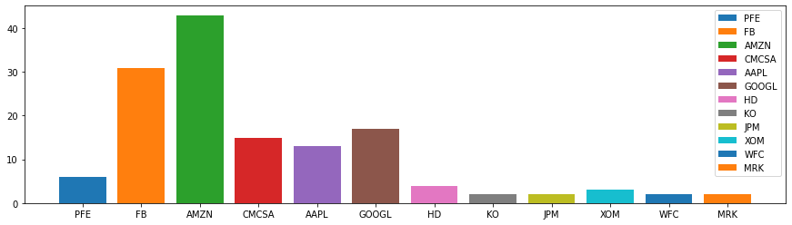

```python
chart_companies = tuple(list(tweets_per_company.keys()))
chart_counts = []

for company in chart_companies:
    chart_counts.append(tweets_per_company[company])

# Making the figure
company_count_fig, company_count_ax = plt.subplots()

company_count_fig.set_figwidth(15)

for index, company in enumerate(chart_companies):
    company_count_ax.bar(company, chart_counts[index], label=company)

company_count_ax.legend(loc='upper right')
```

From the chart above, it seems clear that Amazon and Facebook were the most mentioned companies in Trump's tweets, followed by Google, Comcast and Apple.

## How did Trump feel about every company?

Below we see the overall sentiment of trump for every company. The higher the number, the more positive he was about the company. The lower, the more negative. Around 0, more on the neutral side.

```python
sentiment_per_company = {}

for index, row in company_tweets.iterrows():
    ticker = row['ticker']
    sentiment = row['sentiment']

    if ticker in sentiment_per_company:
        sentiment_per_company[ticker] += sentiment
    else:
        sentiment_per_company[ticker] = sentiment
```

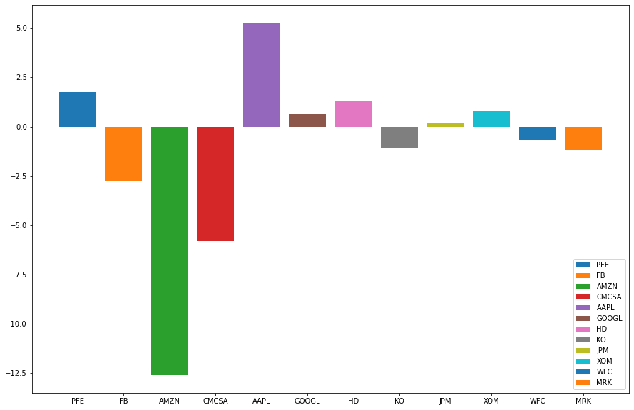

```python
sentiment_companies = tuple(list(sentiment_per_company.keys()))
sentiment_counts = []

for company in sentiment_companies:
    sentiment_counts.append(sentiment_per_company[company])

# Making the figure
sentiment_count_fig, sentiment_count_ax = plt.subplots()

sentiment_count_fig.set_figwidth(15)
sentiment_count_fig.set_figheight(10)

for index, company in enumerate(sentiment_companies):
    sentiment_count_ax.bar(company, sentiment_counts[index], label=company)

sentiment_count_ax.legend(loc='lower right')
```

From the chart above, it seems that Trump liked Pfizer, Apple and Home Depot, liking Apple the most. On the other hand, he seems to have disliked Facebook, and really disliked Comcast and Amazon.

## How did these companies do overall?

```python
stocks_as_lists = {}
sp500_lists = [[], []]

ticker_keys = list(set(list(company_tweets['ticker'])))

for ticker in ticker_keys:
    # First list is dates
    # Second list is open price
    stocks_as_lists[ticker] = [[], []]

for ticker in ticker_keys:
    table = stock_tables[ticker]

    for index, row in (table.sort_values(by=['date'])).iterrows():
        stocks_as_lists[ticker][0].append(row['date'])
        stocks_as_lists[ticker][1].append(row['Open'])


for index, row in (sp500_table.sort_values(by=['date'])).iterrows():
    sp500_lists[0].append(row['date'])
    sp500_lists[1].append(row['Open'])
```

### All but Amazon and Google

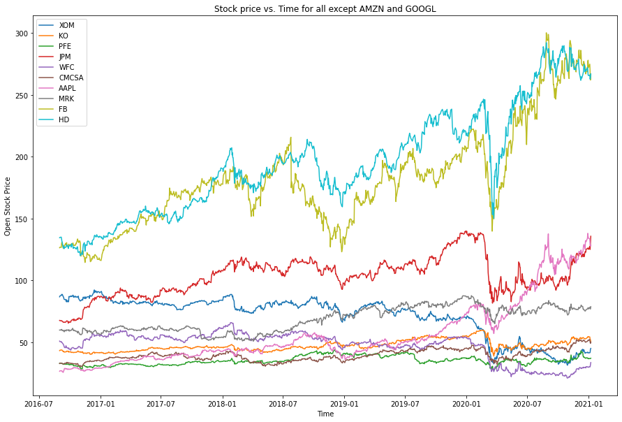

```python
# Plotting it

fig, ax = plt.subplots()

ax.set_xlabel('Time')
ax.set_ylabel('Open Stock Price')
ax.set_title('Stock price vs. Time for all except AMZN and GOOGL')

fig.set_figwidth(15)
fig.set_figheight(10)

for ticker in stocks_as_lists.keys():
    if ticker != 'AMZN' and ticker != 'GOOGL':
        x = stocks_as_lists[ticker][0]
        y = stocks_as_lists[ticker][1]
        ax.plot(x, y, label=ticker)

ax.legend(loc='upper left')
```

### Google and Amazon

Why separate them from the rest? It turns out that Amazon and Google are worth significantly more than the rest of the stocks. So much more, than it doesn't make sense to graph them together

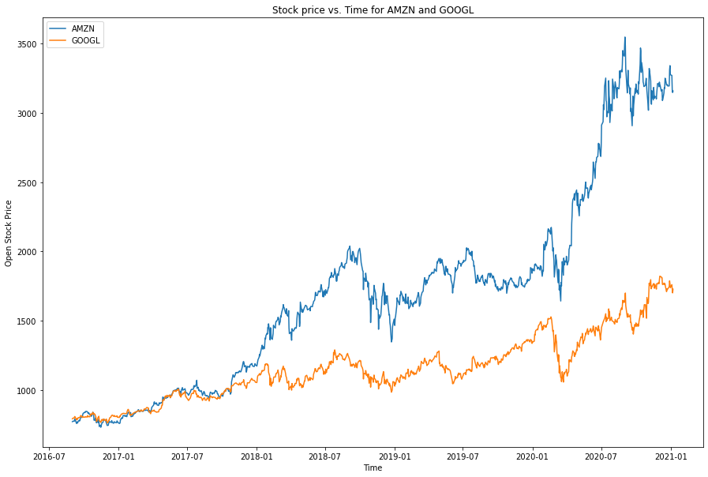

```python
g_and_a_fig, g_and_a_ax = plt.subplots()

g_and_a_ax.set_xlabel('Time')
g_and_a_ax.set_ylabel('Open Stock Price')
g_and_a_ax.set_title('Stock price vs. Time for AMZN and GOOGL')

g_and_a_fig.set_figwidth(15)
g_and_a_fig.set_figheight(10)

for ticker in stocks_as_lists.keys():
    if ticker == 'AMZN' or ticker == 'GOOGL':
        x = stocks_as_lists[ticker][0]
        y = stocks_as_lists[ticker][1]
        g_and_a_ax.plot(x, y, label=ticker)

g_and_a_ax.legend(loc='upper left')
```

### Value of the S&P500 over time

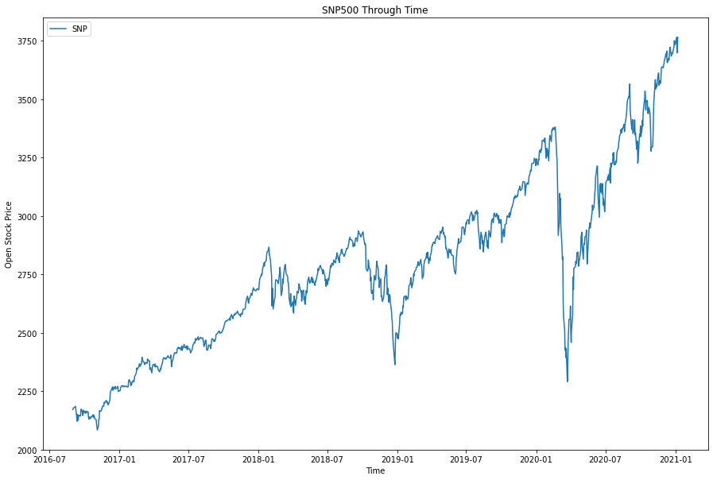

```python
sp500_fig, sp500_ax = plt.subplots()

sp500_ax.set_xlabel('Time')
sp500_ax.set_ylabel('Open Stock Price')
sp500_ax.set_title('SNP500 Through Time')

sp500_fig.set_figwidth(15)
sp500_fig.set_figheight(10)

x = sp500_lists[0]
y = sp500_lists[1]
sp500_ax.plot(x, y, label='SNP')

sp500_ax.legend(loc='upper left')
```

## Stocks and Tweets

Let's see what the price of stocks were when Trump tweeted about them. Does it look like the tweets happened before they went up or down? Do they seems to have any effect at all?

### Amazon and Google

First, we will get all the dates of the tweets that mention Amazon and Google, and correlate them with the dates of the stock prices, in order to plot them scattered around the plot.

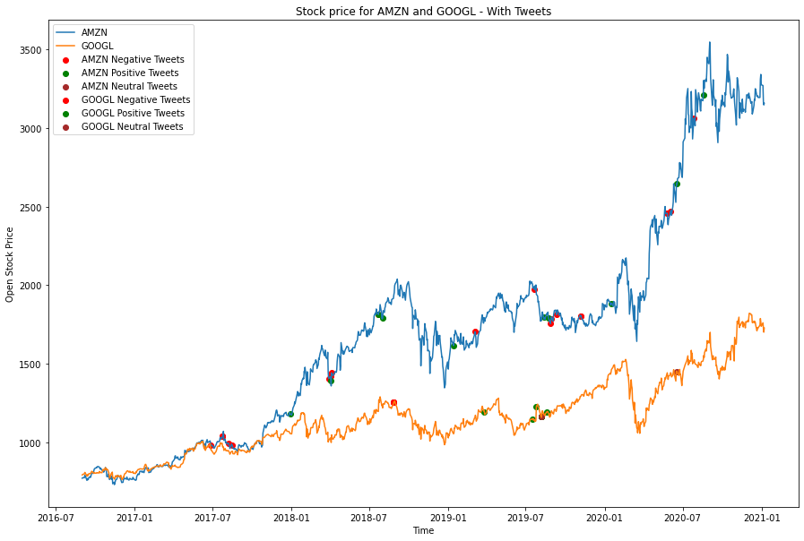

```python
# Creating the plots
top_with_scatter_fig, top_with_scatter_ax = plt.subplots()

top_with_scatter_ax.set_xlabel('Time')
top_with_scatter_ax.set_ylabel('Open Stock Price')
top_with_scatter_ax.set_title('Stock price for AMZN and GOOGL - With Tweets')

top_with_scatter_fig.set_figwidth(15)
top_with_scatter_fig.set_figheight(10)

# Plotting the stock price per day for Amazon and Google
for ticker in stocks_as_lists.keys():
    if ticker == 'AMZN' or ticker == 'GOOGL':
        x = stocks_as_lists[ticker][0]
        y = stocks_as_lists[ticker][1]
        top_with_scatter_ax.plot(x, y, label=ticker)



positive_google_tweets = [[], []]
neutral_google_tweets = [[], []]
negative_google_tweets = [[], []]
positive_amazon_tweets = [[], []]
neutral_amazon_tweets = [[], []]
negative_amazon_tweets = [[], []]

# Getting every position of a tweet, along with its compound sentiment for scattering
for index, row in company_tweets.iterrows():

    ticker = row['ticker']

    if ticker == 'AMZN' or ticker == 'GOOGL':

        # Get the date of the tweet, and get rid of the non-date part
        date = row['date'].date()
        sentiment = row['sentiment']

        # Need a try except here, because there are days where stock market data is not available
        # This is normal, since we have holidays, Sundays, etc. It seems however,
        # that Trump's tweets did not take any vacations.
        try:
            date_index = stocks_as_lists[ticker][0].index(date)
            price = stocks_as_lists[ticker][1][date_index]

            if ticker == 'AMZN':
                if sentiment > 0:
                    positive_amazon_tweets[0].append(date)
                    positive_amazon_tweets[1].append(price)
                elif sentiment < 0:
                    negative_amazon_tweets[0].append(date)
                    negative_amazon_tweets[1].append(price)
                else:
                    neutral_amazon_tweets[0].append(date)
                    neutral_amazon_tweets[1].append(price)
            else:
                if sentiment > 0:
                    positive_google_tweets[0].append(date)
                    positive_google_tweets[1].append(price)
                elif sentiment < 0:
                    negative_google_tweets[0].append(date)
                    negative_google_tweets[1].append(price)
                else:
                    neutral_google_tweets[0].append(date)
                    neutral_google_tweets[1].append(price)

        # Price for the stock that day was unavailable
        except ValueError:
            continue


top_with_scatter_ax.scatter(negative_amazon_tweets[0], negative_amazon_tweets[1], label='AMZN Negative Tweets', color='red')
top_with_scatter_ax.scatter(positive_amazon_tweets[0], positive_amazon_tweets[1], label='AMZN Positive Tweets', color='green')
top_with_scatter_ax.scatter(neutral_amazon_tweets[0], neutral_amazon_tweets[1], label='AMZN Neutral Tweets', color='brown')

top_with_scatter_ax.scatter(negative_google_tweets[0], negative_google_tweets[1], label='GOOGL Negative Tweets', color='red')
top_with_scatter_ax.scatter(positive_google_tweets[0], positive_google_tweets[1], label='GOOGL Positive Tweets', color='green')
top_with_scatter_ax.scatter(neutral_google_tweets[0], neutral_google_tweets[1], label='GOOGL Neutral Tweets', color='brown')

top_with_scatter_ax.legend(loc='upper left')
```

At first glance, it wouldn't seem that Trump's tweets had much of an effect if none at all. However, one interesting that we can see is that there were a concentration of tweets about Amazon around March or April of 2018, followed by a raise in price shortly after. Still, these tweets were both positive and negative, so there's definitely nothing conclusive we could say from this graph.

### Restricting the Window of Time

It is currently hard to see whether we might draw any correlations between Trump's tweets and a raise or fall in the price of a stock. So, let's try using a smaller window of time. By observation, it seems the period from 2018-01 to 2019-01 might be worth investigating, as Amazon's stock seems to have been going up and down considerably. Google's stock remained somewhat more stable during the same period of time, while the other stocks were all over the place, some stable and some not.

In contrast, the S&P500 seems to have had a major dip during the time, so it might yield some interesting results to limit our more in-depth analysis to this window of time.

```python
window_stocks_as_lists = {}
window_sp500_lists = [[], []]

ticker_keys = list(set(list(company_tweets['ticker'])))

for ticker in ticker_keys:
    # First list is dates
    # Second list is open price
    window_stocks_as_lists[ticker] = [[], []]

for ticker in ticker_keys:

    table = stock_tables[ticker]
    table = table[table['date'] > datetime(2018, 1, 1)]
    table = table[table['date'] < datetime(2019,1,2)]

    for index, row in (table.sort_values(by=['date'])).iterrows():
        window_stocks_as_lists[ticker][0].append(row['date'])
        window_stocks_as_lists[ticker][1].append(row['Open'])


sp500_copy = sp500_table
sp500_copy = sp500_copy[sp500_copy['date'] > datetime(2018, 1, 1)]
sp500_copy = sp500_copy[sp500_copy['date'] < datetime(2019,1,2)]

for index, row in (sp500_table.sort_values(by=['date'])).iterrows():
    window_sp500_lists[0].append(row['date'])
    window_sp500_lists[1].append(row['Open'])
```

### Windowed: All but Amazon and Google

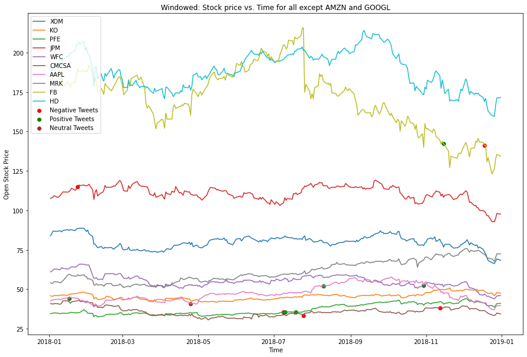

```python
# Plotting it

positive_tweets = [[],[]]
neutral_tweets = [[],[]]
negative_tweets = [[],[]]

# Getting every position of a tweet, along with its compound sentiment for scattering
for index, row in company_tweets.iterrows():

    ticker = row['ticker']

    if ticker != 'AMZN' and ticker != 'GOOGL':

        # Get the date of the tweet, and get rid of the non-date part
        date = row['date'].date()
        sentiment = row['sentiment']

        # Need a try except here, because there are days where stock market data is not available
        # This is normal, since we have holidays, Sundays, etc. It seems however,
        # that Trump's tweets did not take any vacations.
        try:
            date_index = window_stocks_as_lists[ticker][0].index(date)
            price = window_stocks_as_lists[ticker][1][date_index]

            if sentiment > 0:
                positive_tweets[0].append(date)
                positive_tweets[1].append(price)
            elif sentiment < 0:
                negative_tweets[0].append(date)
                negative_tweets[1].append(price)
            else:
                neutral_tweets[0].append(date)
                neutral_tweets[1].append(price)

        except ValueError:
            # Price for the stock that day was unavailable
            continue

window_fig, window_ax = plt.subplots()

window_ax.set_xlabel('Time')
window_ax.set_ylabel('Open Stock Price')
window_ax.set_title('Windowed: Stock price vs. Time for all except AMZN and GOOGL')

window_fig.set_figwidth(15)
window_fig.set_figheight(10)

for ticker in window_stocks_as_lists.keys():
    if ticker != 'AMZN' and ticker != 'GOOGL':
        x = window_stocks_as_lists[ticker][0]
        y = window_stocks_as_lists[ticker][1]
        window_ax.plot(x, y, label=ticker)

window_ax.scatter(negative_tweets[0], negative_tweets[1], label='Negative Tweets', color='red')
window_ax.scatter(positive_tweets[0], positive_tweets[1], label='Positive Tweets', color='green')
window_ax.scatter(neutral_tweets[0], neutral_tweets[1], label='Neutral Tweets', color='brown')

window_ax.legend(loc='upper left')
```

Even though we do not have lots of tweets for each company, it seems that there is no obvious correlation when looking at it visually.

Towards the beginning of November of 2018 we can see a positive tweet for Facebook, followed by it stocks going down. We can then see in December a negative tweet, followed by the stock going down.

For other stocks, there doesn't seem to be much movement related to the tweets at all.

### Windowed: Amazon and Google with Tweets

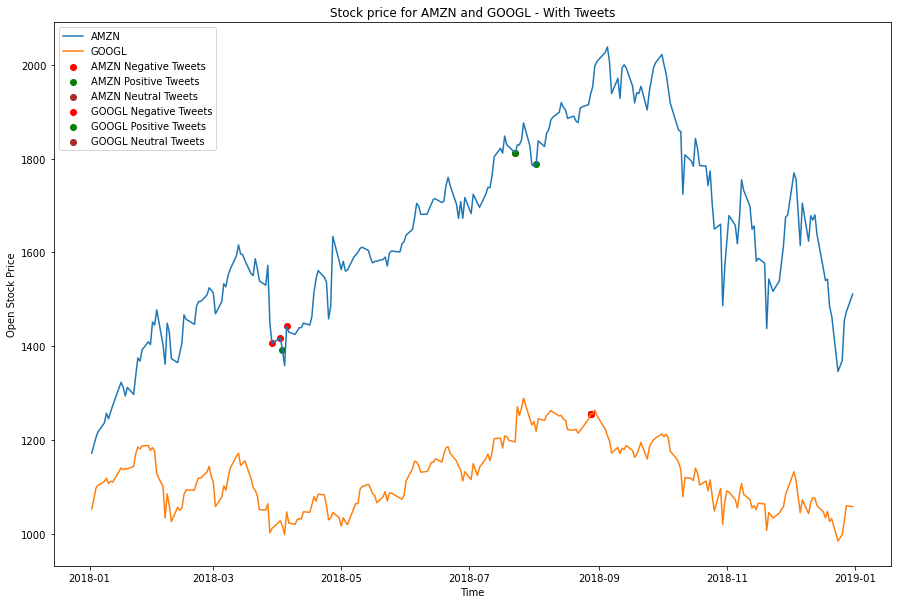

```python
# Creating the plots
window_top_with_scatter_fig, window_top_with_scatter_ax = plt.subplots()

window_top_with_scatter_ax.set_xlabel('Time')
window_top_with_scatter_ax.set_ylabel('Open Stock Price')
window_top_with_scatter_ax.set_title('Stock price for AMZN and GOOGL - With Tweets')

window_top_with_scatter_fig.set_figwidth(15)
window_top_with_scatter_fig.set_figheight(10)

for ticker in window_stocks_as_lists.keys():
    if ticker == 'AMZN' or ticker == 'GOOGL':
        x = window_stocks_as_lists[ticker][0]
        y = window_stocks_as_lists[ticker][1]
        window_top_with_scatter_ax.plot(x, y, label=ticker)



positive_google_tweets = [[], []]
neutral_google_tweets = [[], []]
negative_google_tweets = [[], []]
positive_amazon_tweets = [[], []]
neutral_amazon_tweets = [[], []]
negative_amazon_tweets = [[], []]

# Getting every position of a tweet, along with its compound sentiment for scattering
for index, row in company_tweets.iterrows():

    ticker = row['ticker']

    if ticker == 'AMZN' or ticker == 'GOOGL':

        # Get the date of the tweet, and get rid of the non-date part
        date = row['date'].date()
        sentiment = row['sentiment']

        # Need a try except here, because there are days where stock market data is not available
        # This is normal, since we have holidays, Sundays, etc. It seems however,
        # that Trump's tweets did not take any vacations.
        try:
            date_index = window_stocks_as_lists[ticker][0].index(date)
            price = window_stocks_as_lists[ticker][1][date_index]
            #print(f'The price of {ticker} was {stocks_as_lists[ticker][1][date_index]} on {date}')

            if ticker == 'AMZN':
                if sentiment > 0:
                    positive_amazon_tweets[0].append(date)
                    positive_amazon_tweets[1].append(price)
                elif sentiment < 0:
                    negative_amazon_tweets[0].append(date)
                    negative_amazon_tweets[1].append(price)
                else:
                    neutral_amazon_tweets[0].append(date)
                    neutral_amazon_tweets[1].append(price)
            else:
                if sentiment > 0:
                    positive_google_tweets[0].append(date)
                    positive_google_tweets[1].append(price)
                elif sentiment < 0:
                    negative_google_tweets[0].append(date)
                    negative_google_tweets[1].append(price)
                else:
                    neutral_google_tweets[0].append(date)
                    neutral_google_tweets[1].append(price)

            #top_with_scatter_ax.scatter(date, stocks_as_lists[ticker][1][date_index],color='red')
        except ValueError:
            # Price for the stock that day was unavailable
            #print(f'Price for {ticker} in {date} was unavailable
            continue


window_top_with_scatter_ax.scatter(negative_amazon_tweets[0], negative_amazon_tweets[1], label='AMZN Negative Tweets', color='red')
window_top_with_scatter_ax.scatter(positive_amazon_tweets[0], positive_amazon_tweets[1], label='AMZN Positive Tweets', color='green')
window_top_with_scatter_ax.scatter(neutral_amazon_tweets[0], neutral_amazon_tweets[1], label='AMZN Neutral Tweets', color='brown')

window_top_with_scatter_ax.scatter(negative_google_tweets[0], negative_google_tweets[1], label='GOOGL Negative Tweets', color='red')
window_top_with_scatter_ax.scatter(positive_google_tweets[0], positive_google_tweets[1], label='GOOGL Positive Tweets', color='green')
window_top_with_scatter_ax.scatter(neutral_google_tweets[0], neutral_google_tweets[1], label='GOOGL Neutral Tweets', color='brown')

window_top_with_scatter_ax.legend(loc='upper left')
```

In this case the correlation seems a bit better. We can see two instances where the price of Amazon increased after positive tweets, and one where it decreased after a positive tweet.

We can also see instances where it increased and decreased with negative tweets. For Google, there was only one negative tweet, followed by the stock going down, but again, not necessarilly any correlation.

# What now? Part 4: Analysis and Hypothesis Testing.

This is not looking promising at all, at least visually. However, there is another thing we might try. Let's run an experiment to see if investing in the stocks that Trump tweeted about positively yielded better results than a control group (such as the S&P500).

We can set up 5 imaginary investors, each with \$100,000. They will operate in the following way:

- Investor #1: 100% invested in the S&P500
- Investor #2: 90% invested in the S&P500, 10% in Trump Tweets
- Investor #3: 80% invested in the S&P500, 20% in Trump Tweets
- Investor #4: 50% invested in the S&P500, 50% in Trump Tweets
- Investor #5: 0% invested in the S&P500, 100% in Trump Tweets

The relevant first percent of their capital will be invested in the S&P500, while the other will be invested on whatever stocks Trump tweets about positively. The way in which we will determine this is that every investor will invest in up to *X* tweets, where *X* is the number of tweets they can afford. The amount they will invest will be \$2,000 per tweet. The reason why is that, with our current range and model, the largest amount of tweets we could possibly invest in (assuming positive) is 57, so this will allow Investor #5 to invest all their capital.

```python
print('How many tweets of each kind?')
print(f"Positive tweets: {len(company_tweets[company_tweets['sentiment'] > 0])}")
print(f"Neutral tweets: {len(company_tweets[company_tweets['sentiment'] == 0])}")
print(f"Negative tweets: {len(company_tweets[company_tweets['sentiment'] < 0])}")
```

```
How many tweets of each kind?
Positive tweets: 57
Neutral tweets: 10
Negative tweets: 73
```

```python
# Gives us the next possible day to buy a stock
def get_next_available_day(date, ticker):
    day_change = otherdate.timedelta(days=1)
    dates = stock_tables[ticker].sort_values(by=['date'])['date'].tolist()

    date = str(date)[:10]
    date = datetime.strptime(date,'%Y-%m-%d')

    date += day_change

    while date not in dates:
        date += day_change

    return date

experiment_tweets = company_tweets.sort_values(by=['date'])

snp_opening_price = sp500_table.at[datetime(2016, 9, 1), 'Open']

investors = []

# Here we set up the initial portfolio for each investor, with the amount of
# stocks in the S&P500, as well as how many $2,000 worth of stocks they can buy
investor_1_stocks = {}
investor_1_stocks['SNP'] = (100000 / snp_opening_price)
investor_1_stocks['can_buy'] = 0

investor_2_stocks = {}
investor_2_stocks['SNP'] = (90000 / snp_opening_price)
investor_2_stocks['can_buy'] = int((100000 - 90000)/2000)

investor_3_stocks = {}
investor_3_stocks['SNP'] = (80000 / snp_opening_price)
investor_3_stocks['can_buy'] = int((100000 - 80000)/2000)

investor_4_stocks = {}
investor_4_stocks['SNP'] = (50000 / snp_opening_price)
investor_4_stocks['can_buy'] = int((100000 - 50000)/2000)

investor_5_stocks = {}
investor_5_stocks['can_buy'] = int((100000 - 0)/2000)

investors = [investor_1_stocks, investor_2_stocks, investor_3_stocks, investor_4_stocks, investor_5_stocks]

investors_money = [[],[],[],[],[]]

# Creating each investor's portfolio:
for index, row in experiment_tweets.iterrows():
    ticker = row['ticker']
    sentiment = row['sentiment']
    date = row['date']

    if sentiment > 0:
        for investor_num, investor in enumerate(investors):

            if investor['can_buy'] > 0:
                next_day = get_next_available_day(date, ticker)
                opening_price = stock_tables[ticker].at[next_day, 'Open']

                investor['can_buy'] -= 1

                stocks_bought = 2000 / opening_price

                if ticker in investor.keys():
                    investor[ticker] += stocks_bought
                else:
                    investor[ticker] = stocks_bought

                investors_money[investor_num].append([next_day, investor.copy()])

# Adding the last one we missed
end_date = get_next_available_day(datetime(2021, 1, 6), 'AMZN')

investors_money[0].append([end_date, investor_1_stocks.copy()])
investors_money[1].append([end_date, investor_2_stocks.copy()])
investors_money[2].append([end_date, investor_3_stocks.copy()])
investors_money[3].append([end_date, investor_4_stocks.copy()])
investors_money[4].append([end_date, investor_5_stocks.copy()])


# Total profits
print('Portfolios: ')
print('=============================================================')
for i, investor in enumerate(investors):
    print(f'Investor {i+1}: {str(investor)}')
    print('=============================================================')

print()
print('How much money did they end up with?')

# Note: Any ticker would work here, just getting the last date in proper formatting
end_date = get_next_available_day(datetime(2021, 1, 6), 'AMZN')

for index, investor in enumerate(investors):
    total = 0
    for key in investor.keys():
        if key != 'can_buy' and key != 'SNP':
            close_price = stock_tables[key].at[end_date, 'Close']
            total += (investor[key] * close_price)
        elif key == 'SNP':
            close_price = sp500_table.at[end_date, 'Close']
            total += (investor[key] * close_price)

    print(f"Investor {index+1}: Ended up with ${total}")
```

```
Portfolios:
=============================================================
Investor 1: {'SNP': 46.05472056388248, 'can_buy': 0}
=============================================================
Investor 2: {'SNP': 41.44924850749424, 'can_buy': 0, 'FB': 76.53760252629424}
=============================================================
Investor 3: {'SNP': 36.84377645110599, 'can_buy': 0, 'FB': 88.38033074854778, 'XOM': 21.67786639595796, 'AMZN': 3.1789784677512998, 'AAPL': 44.60054757080956}
=============================================================
Investor 4: {'SNP': 23.02736028194124, 'can_buy': 0, 'FB': 116.06663817123854, 'XOM': 21.67786639595796, 'AMZN': 8.776146908195633, 'AAPL': 119.02865602529252, 'PFE': 113.25727085868118, 'WFC': 37.707389997697085, 'GOOGL': 3.382513945994191, 'HD': 9.422850412249705}
=============================================================
Investor 5: {'can_buy': 0, 'FB': 145.78705642717838, 'XOM': 21.67786639595796, 'AMZN': 13.162664735039327, 'AAPL': 355.7673409848148, 'PFE': 113.25727085868118, 'WFC': 37.707389997697085, 'GOOGL': 15.312718180684245, 'HD': 19.400401075502728, 'CMCSA': 140.53571290728536}
=============================================================

How much money did they end up with?
Investor 1: Ended up with $175182.48733270308
Investor 2: Ended up with $178232.95315491158
Investor 3: Ended up with $180763.49782024
Investor 4: Ended up with $177060.9696879007
Investor 5: Ended up with $173265.8900661125
```

It seems like all investors made a profit. However, the difference between the amount of money they made does not seem that significant.

The difference between Investor #3's profit and Investor #1's was of close to \$5600, which is not insignificant. However, past 20\% of the \\$100,000 portfolio invested in Trump tweets seems to start having diminishing returns, as 50\% and 100\% of the portfolio made less money, and 100\% made less than Investor #1 (the control).

We can visualize this in the plot below, but first we need to calculate the profits for each investor, each day.

```python
# Getting each investors profit per day
def get_profits(stocks, date):
    total = 0
    for key in stocks.keys():

        if key != 'can_buy' and key != 'SNP':
            stock_close_price = stock_tables[key].at[date, 'Close']
            total += (stocks[key] * stock_close_price)
        elif key == 'SNP':
            close_price = sp500_table.at[date, 'Close']
            total += (stocks[key] * close_price)

    return total

# Investor 1's profits:

investor_1_days = sp500_table.sort_values(by=['date'])['date'].tolist()
investor_1_profits = sp500_table.sort_values(by=['date'])['Close'].tolist()
investor_1_profits = [(lambda x: x * investor_1_stocks['SNP'])(x) for x in investor_1_profits]

# Investor 2's profits
investor_2_days = []
investor_2_profits = []

for i in range(0, len(investors_money[1])-1):
    curr_date = investors_money[1][i][0]

    next_day = investors_money[1][i+1][0]

    stocks = investors_money[1][i][1]


    while curr_date < next_day:
        investor_2_days.append(curr_date)
        investor_2_profits.append(get_profits(stocks, curr_date))

        curr_date = get_next_available_day(curr_date, 'AMZN')

# Investor 3's profits
investor_3_days = []
investor_3_profits = []

for i in range(0, len(investors_money[2])-1):
    curr_date = investors_money[2][i][0]

    next_day = investors_money[2][i+1][0]

    stocks = investors_money[2][i][1]


    while curr_date < next_day:
        investor_3_days.append(curr_date)
        investor_3_profits.append(get_profits(stocks, curr_date))

        curr_date = get_next_available_day(curr_date, 'AMZN')

# Investor 4's profits
investor_4_days = []
investor_4_profits = []

for i in range(0, len(investors_money[3])-1):
    curr_date = investors_money[3][i][0]

    next_day = investors_money[3][i+1][0]

    stocks = investors_money[3][i][1]


    while curr_date < next_day:
        investor_4_days.append(curr_date)
        investor_4_profits.append(get_profits(stocks, curr_date))

        curr_date = get_next_available_day(curr_date, 'AMZN')

# Investor 5's profits
investor_5_days = []
investor_5_profits = []

for i in range(0, len(investors_money[4])-1):
    curr_date = investors_money[4][i][0]

    next_day = investors_money[4][i+1][0]

    stocks = investors_money[4][i][1]


    while curr_date < next_day:
        investor_5_days.append(curr_date)
        investor_5_profits.append(get_profits(stocks, curr_date))

        curr_date = get_next_available_day(curr_date, 'AMZN')
```

Let's graph each investors profit to see how they did:

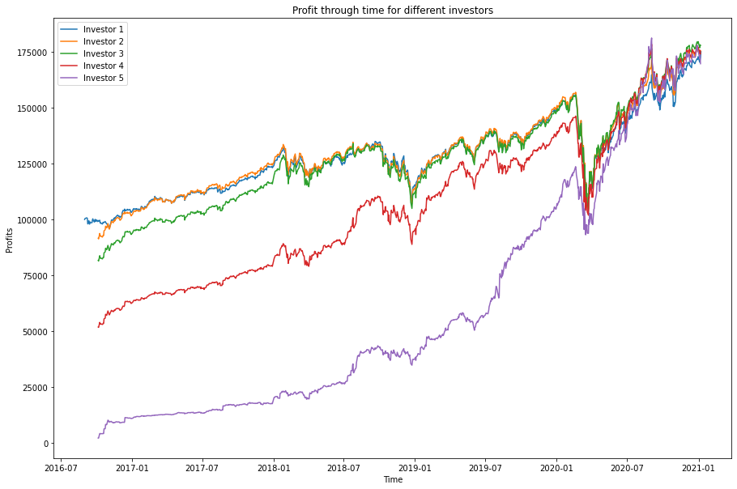

```python
# Making the plot
investors_fig, investors_ax = plt.subplots()

investors_ax.set_xlabel('Time')
investors_ax.set_ylabel('Profits')
investors_ax.set_title('Profit through time for different investors')

investors_fig.set_figwidth(15)
investors_fig.set_figheight(10)

investors_ax.plot(investor_1_days, investor_1_profits, label='Investor 1')
investors_ax.plot(investor_2_days, investor_2_profits, label='Investor 2')
investors_ax.plot(investor_3_days, investor_3_profits, label='Investor 3')
investors_ax.plot(investor_4_days, investor_4_profits, label='Investor 4')
investors_ax.plot(investor_5_days, investor_5_profits, label='Investor 5')

investors_ax.legend(loc='upper left')
```

Again, the difference in profit now looks just as insignificant if not more. It seems we were not able to find much of an effect to discard the null hypothesis.

# Part 5: Insight and Conclusion

From what we see in our findings and our exploration, there doesn't seem to be a major significant difference between having invested in stocks that were mentioned by Trump and those that weren't.

We defined our margin of error to be 5%, so that if we found that overall we would've made more than 5% more investing in the stocks we found in Trump's tweets, we would determine the null hypothesis to be false.

We did find this was the case, when we invested 20% of our portfolio into the stocks, and the other 80% in the S&P500, we found an edge of a bit over 5%. However, for all other scenarios, the difference was less than 5%. Even more, when investing more than 20%, the returns started to diminish, and even fell below the control (Investor #1) for 100% of the portfolio invested in stocks (Investor #5).